# Modern Data Mining, HW 1

# 2 Case study 1: Audience Size

How successful is the Wharton Talk Show [Business Radio Powered by the Wharton School](https://businessradio.wharton.upenn.edu/)

**Background:** Have you ever listened to [SiriusXM](https://www.siriusxm.com/)? Do you know there is a **Talk Show** run by Wharton professors in Sirius Radio? Wharton launched a talk show called [Business Radio Powered by the Wharton School](https://businessradio.wharton.upenn.edu/) through the Sirius Radio station in January of 2014. Within a short period of time the general reaction seemed to be overwhelmingly positive. To find out the audience size for the show, we designed a survey and collected a data set via MTURK in May of 2014. Our goal was to **estimate the audience size**. There were 51.6 million Sirius Radio listeners then. One approach is to estimate the proportion of the Wharton listeners to that of the Sirius listeners, $p$, so that we will come up with an audience size estimate of approximately 51.6 million times $p$.

To do so, we launched a survey via Amazon Mechanical Turk ([MTurk](https://www.mturk.com/)) on May 24, 2014 at an offered price of $0.10 for each answered survey. We set it to be run for 6 days with a target maximum sample size of 2000 as our goal. Most of the observations came in within the first two days. The main questions of interest are “Have you ever listened to Sirius Radio” and “Have you ever listened to Sirius Business Radio by Wharton?”. A few demographic features used as control variables were also collected; these include Gender, Age and Household Income.

We requested that only people in United States answer the questions. Each person can only fill in the questionnaire once to avoid duplicates. Aside from these restrictions, we opened the survey to everyone in MTurk with a hope that the sample would be more randomly chosen.

The raw data is stored as `Survey_results_final.csv` on Canvas.

## 2.1 Data preparation

1. We need to clean and select only the variables of interest.

Select only the variables Age, Gender, Education Level, Household Income in 2013, Sirius Listener?, Wharton Listener? and Time used to finish the survey.

Change the variable names to be “age”, “gender”, “education”, “income”, “sirius”, “wharton”, “worktime”.

```r
d0 <- read.csv('data/Survey_results_final.csv', header = T) |>
  select(Answer.Age, Answer.Gender, Answer.Education, Answer.HouseHoldIncome, Answer.Sirius.Radio, Answer.Wharton.Radio, WorkTimeInSeconds) |>
  rename(age = Answer.Age,
         gender = Answer.Gender,
         education = Answer.Education,
         income = Answer.HouseHoldIncome,
         sirius = Answer.Sirius.Radio,
         wharton = Answer.Wharton.Radio,
         worktime = WorkTimeInSeconds)

names(d0)
```

```
## [1] "age"       "gender"    "education" "income"    "sirius"    "wharton"
## [7] "worktime"
```

2. Handle missing/wrongly filled values of the selected variables

As in real world data with user input, the data is incomplete, with missing values, and has incorrect responses. There is no general rule for dealing with these problems beyond “use common sense.” In whatever case, explain what the problems were and how you addressed them. Be sure to explain your rationale for your chosen methods of handling issues with the data. Do not use Excel for this, however tempting it might be.

```r
## assign NA for empty strings
d0 <- d0 %>%
  mutate(across(where(is.character), ~na_if(., "")))


## age
#table(d0$age)

d0 <- d0 |>
  mutate(age = case_when(
    age == "27`" ~ "27",                   # Change '27`' to '27'
    age == "Eighteen (18)" ~ "18",         # Change 'Eighteen (18)' to '18'
    TRUE ~ age                             # Set all other values to age
  )) |>
  mutate(age = as.numeric(age),                   # Convert age to numeric
  age = case_when(
    age > 100 | age < 18 ~ NA_real_,                  # Replace age > 100 with NA
    TRUE ~ age                             # Keep all other ages as they are
  ))


## gender
# table(d0$gender) # good


## education
# table(d0$education)
d0 <- d0 |>
  mutate(education = case_when(
    education %in% c("Other", "select one") ~ NA_character_,
    TRUE ~ education
  ))

## income
# table(d0$income) # good


## sirius
# table(d0$sirius) # good

## wharton
# table(d0$wharton) # good

## worktime
# table(d0$worktime) # good
```

Tip: Reflect on the reasons for which data could be wrong or missing. How would you address each case? For this homework, if you are trying to predict missing values with regression, you are definitely overthinking. Keep it simple.

3. Brief summary

Write a brief report to summarize all the variables collected. Include both summary statistics (including sample size) and graphical displays such as histograms or bar charts where appropriate. Comment on what you have found from this sample. (For example - it’s very interesting to think about why would one work for a job that pays only 10cents/each survey? Who are those survey workers? The answer may be interesting even if it may not directly relate to our goal.)

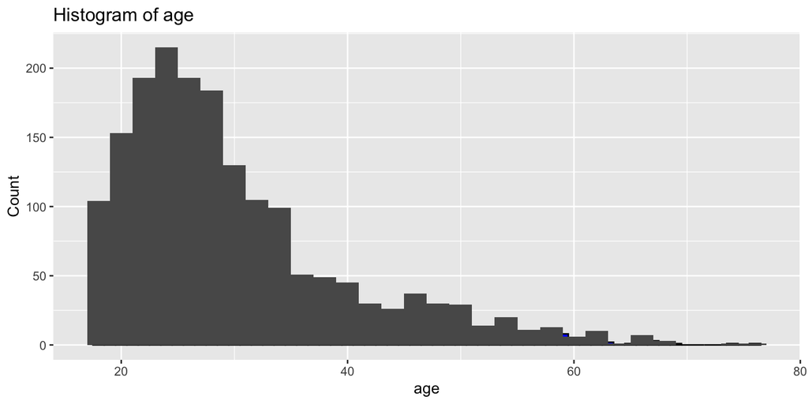

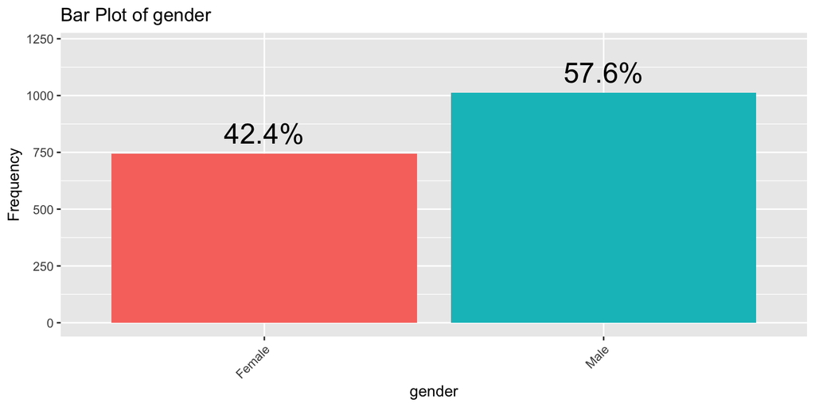

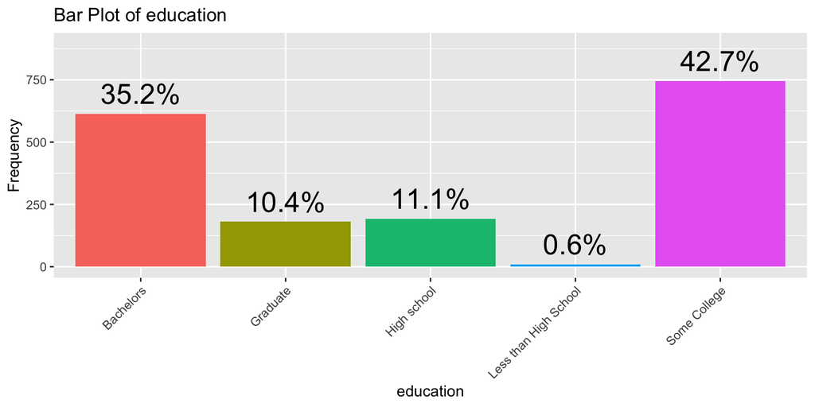

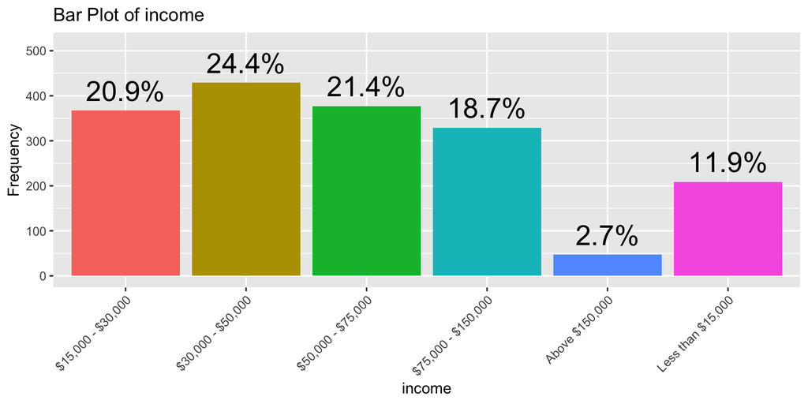

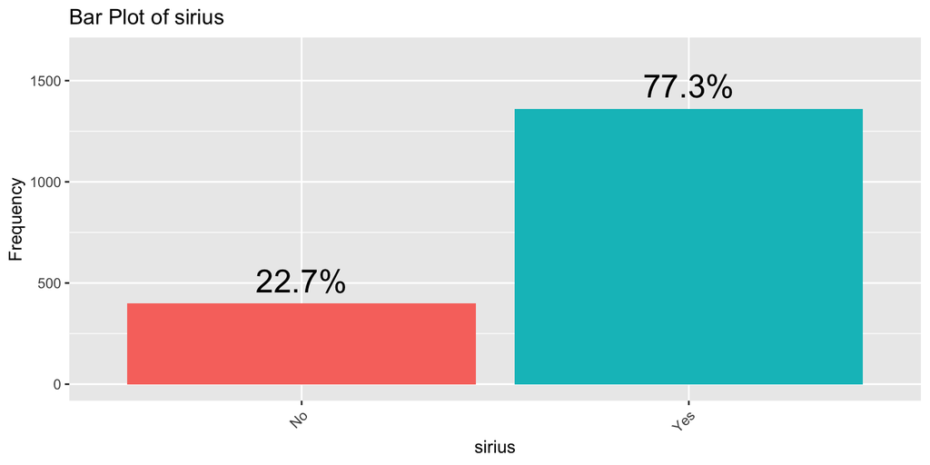

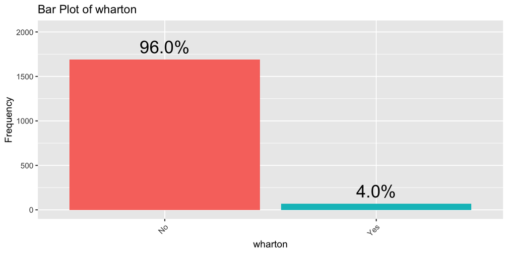

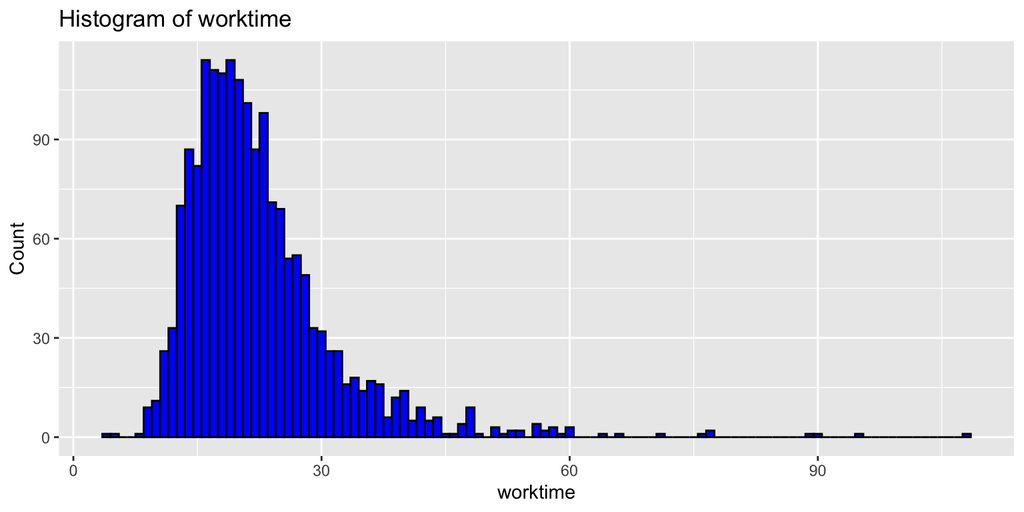

```r
summarize_data <- function(df) {
  for (column_name in names(df)) {
    data <- df[[column_name]]

    cat("\n\nSummary for column:", column_name, "\n")

    if (is.numeric(data)) {
      # Numeric summary
      summary_stats <- summary(data)
      print(summary_stats)

      # Histogram using ggplot2
      p <- ggplot(df, aes(x = .data[[column_name]])) +
        geom_histogram(binwidth = 1, fill = "blue", color = "black") +
        labs(title = paste("Histogram of", column_name), x = column_name, y = "Count")+
        theme(legend.position = "none")

      # Handling NA values explicitly
      if (any(is.na(data))) {
        p <- p + geom_histogram(data = df[!is.na(df[[column_name]]), ], aes(x = .data[[column_name]]))
      }

    } else if (is.factor(data) || is.character(data)) {
      # Categorical summary
      cat_table <- data.frame(table(data))
      total <- sum(cat_table$Freq)
      cat_table$Perc <- (cat_table$Freq / total) * 100
      # Find the maximum frequency to adjust ylim
      max_freq <- max(cat_table$Freq)

  # Bar Plot using ggplot2
    p <- ggplot(cat_table, aes(x = data, y = Freq, fill = data)) +
      geom_bar(stat = "identity") +
      geom_text(aes(label = sprintf("%.1f%%", Perc)), vjust = -0.5, size = 7, position = position_stack(vjust = 1)) +
      labs(title = paste("Bar Plot of", column_name), x = column_name, y = "Frequency") +
      theme(axis.text.x = element_text(angle = 45, hjust = 1)) +
      ylim(0, max_freq * 1.2)+  # Increase ylim by 20%
      theme(legend.position = "none")


    }
    print(p)
  }
}
# Define the mapping from old to new names so it can fit in the graph
education_mapping <- c(
  "Bachelor’s degree or other 4-year degree" = "Bachelors",
  "Some college, no diploma; or Associate’s degree" = "Some College",
  "Graduate or professional degree" = "Graduate",
  "High school graduate (or equivalent)" = "High school",
  "Less than 12 years; no high school diploma" = "Less than High School"
)

# Replace the values in the dataframe
d0$education <- factor(education_mapping[d0$education])

summarize_data(d0)
```

## 2.2 Sample properties

The population from which the sample is drawn determines where the results of our analysis can be applied or generalized. We include some basic demographic information for the purpose of identifying sample bias, if any exists. Combine our data and the general population distribution in age, gender and income to try to characterize our sample on hand.

1. Does this sample appear to be a random sample from the general population of the USA? Why it is crucial to have randomness here?
2. Does this sample appear to be a random sample from the MTURK population?

## 2.3 Final estimate

Give a final estimate of the Wharton audience size by May of 2014. Assume that the sample is a random sample of the MTURK population, and that the proportion of Wharton listeners vs. Sirius listeners in the general population is the same as that in the MTURK population. Write a brief executive summary to summarize your findings and how you came to that conclusion.

The primary goal of this study was to estimate the audience size for the Wharton School’s talk show on Sirius Radio, “Business Radio Powered by the Wharton School,” as of May 2014. This estimation aimed to understand the show’s reach among Sirius Radio listeners, leveraging a survey conducted via Amazon Mechanical Turk (MTurk).

Total Sirius Listeners: 1,365 Wharton Listeners Count: 68 Proportion Wharton: 0.0498

No Yes 1690 70

## 2.4 New task

Now suppose you are asked to design a study to estimate the audience size of Wharton Business Radio Show as of today: You are given a budget of $1000. You need to present your findings in two months.

Write a proposal for this study which includes:

1. Method proposed to estimate the audience size.
2. What data should be collected and where it should be sourced from. (Can we use ChatGPT to get us a rough estimate?)

Please fill in the google form to list your platform where surveys will be launched and collected [HERE](https://forms.gle/8SmjFQ1tpqr6c4sa8)

A good proposal will give an accurate estimation with the least amount of money used.

# 3 Case study 2: Women in Science

Are women underrepresented in science in general? How does gender relate to the type of educational degree pursued? Does the number of higher degrees increase over the years? In an attempt to answer these questions, we assembled a data set (`WomenData_06_16.xlsx`) from [NSF](https://ncses.nsf.gov/pubs/nsf19304/digest/field-of-degree-women) about various degrees granted in the U.S. from 2006 to 2016. It contains the following variables: Field (Non-science-engineering (`Non-S&E`) and sciences (`Computer sciences`, `Mathematics and statistics`, etc.)), Degree (`BS`, `MS`, `PhD`), Sex (`M`, `F`), Number of degrees granted, and Year.

Our goal is to answer the above questions only through EDA (Exploratory Data Analyses) without formal testing. We have provided sample R-codes in the appendix to help you if needed.

## 3.1 Data preparation

1. Understand and clean the data

Notice the data came in as an Excel file. We need to use the package `readxl` and the function `read_excel()` to read the data `WomenData_06_16.xlsx` into R.

a). Read the data into R.

b). Clean the names of each variables. (Change variable names to `Field`,`Degree`, `Sex`, `Year` and `Number` )

I inspected the variable names by looking at head(wsci). Only “Field and sex” and “Degrees Awarded” are not the correct names, so I rename those.

c). Set the variable natures properly. I inspected the variable natures using str(wsci). Field, Degree, and Sex are strings, which is appropriate for their data. Year and Number are numeric, which are also appropriate.

d). Any missing values? I checked for missing values by inspecting the summary of wsci, the table of values for each variable, and calculating the sum of all NA values. This reveals that there are no missing values. All columns have the same length, and there are no null values in any of the columns.

2. Write a summary describing the data set provided here.

a). How many fields are there in this data? I found the number of fields by looking at the length of the list of unique values in Field. There are 10 unique fields.

b). What are the degree types? I got the degree types by looking at the unique values in Degree. They are BS, MS, PhD.

c). How many year’s statistics are being reported here? I found this by looking at the length of the list of unique values in Year. There are 11 years of statistics in this dataset.

## 3.2 BS degrees in 2015

Is there evidence that more males are in science-related fields vs `Non-S&E`? Provide summary statistics and a plot which shows the number of people by gender and by field. Write a brief summary to describe your findings.

To examine this, I filtered the data to include just data on BS degrees from 2015. Then, I looked at summary statistics of the number of degrees earned by men and women and plotted the number of S&E and non-S&E degrees earned by men and women.

There is not evidence that there are more males in science-related fields. In 2015, 327122 males earned S&E degrees and 493304 males earned non-S&E degrees, indicating that there are fewer males in science-related fields. Additionally, there is not evidence that there are more men than women obtaining S&E BS degrees. In 2015, 322935 women and 327122 earned S&E degrees, showing that roughly the same number of females as males obtained S&E degrees.

[output not shown]

[output not shown]

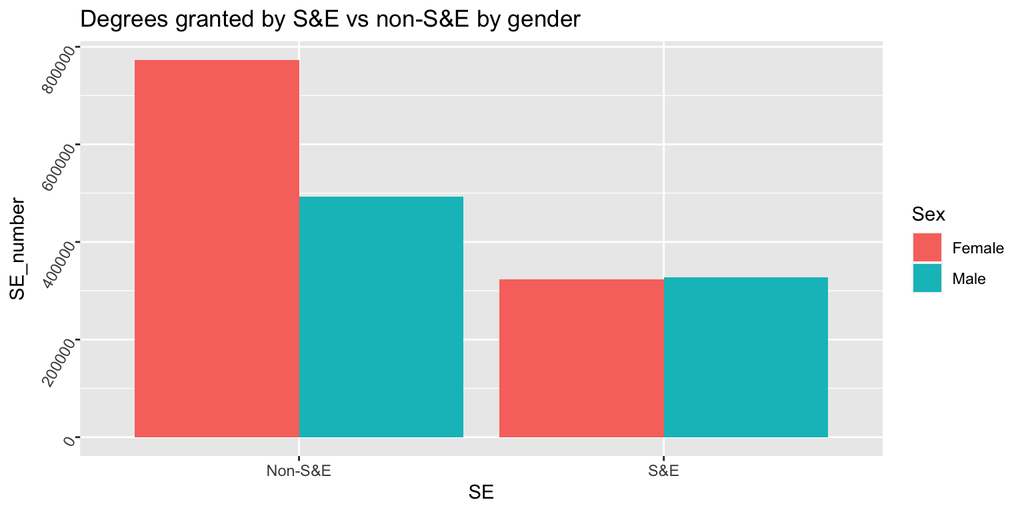

## 3.3 EDA bringing type of degree, field and gender in 2015

Describe the number of people by type of degree, field, and gender. Do you see any evidence of gender effects over different types of degrees? Again, provide graphs to summarize your findings.

When we include the Degree in our analyses, we see that overall, more women than men pursue degrees at the BS, MS, and PhD levels. When we consider S&E vs non-S&E fields, more men than women earn S&E degrees at the MS and PhD levels. Once we include all fields, we notice larger gender effects for non-S&E, psychology, biological sciences, and engineering fields across all degrees. For non-S&E, psychology, and biological sciences degrees, more women than men pursue these. On the other hand, for engineering degrees, more men than women pursue these.

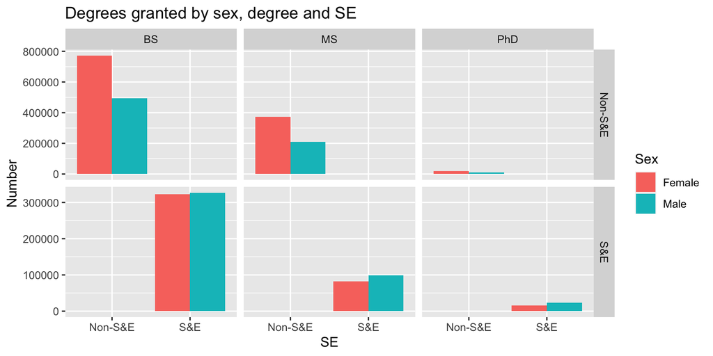

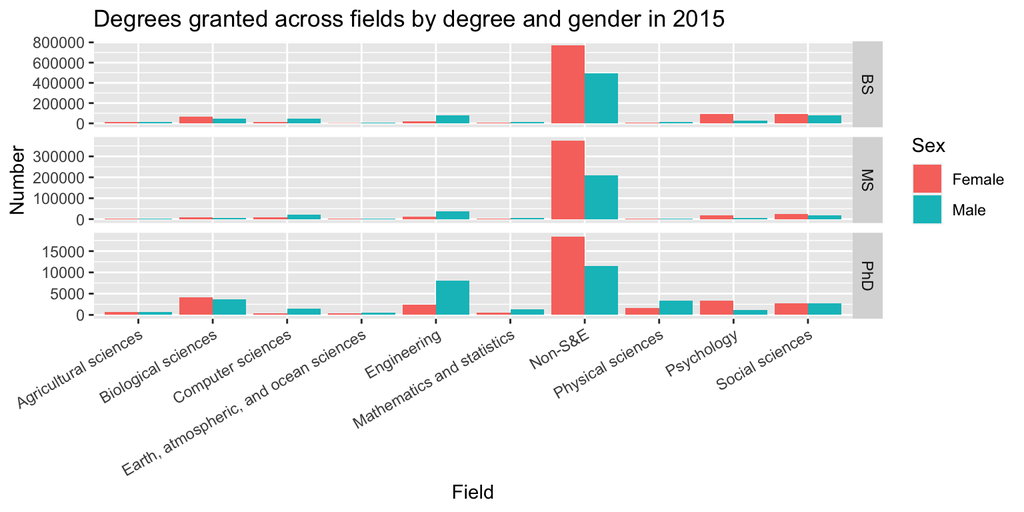

## 3.4 EDA bring all variables

In this last portion of the EDA, we ask you to provide evidence numerically and graphically: Do the number of degrees change by gender, field, and time?

When we display the proportion of females in each degree over time, we see that the relative proportion of females remains fairly stable over time for most fields in all degrees. We can also examine the number of degrees earned by gender. When we only consider females, we see overall increases in the number of degrees earned across all fields and degree types. We see the same trend when we only consider males. Comparing females with males, more women than men pursue degrees across all degree types. For both men and women, non S&E degrees are the most pursued degree. Excluding these from our analysis, we see that consistently more men than women pursue engineering degrees across all degree types.

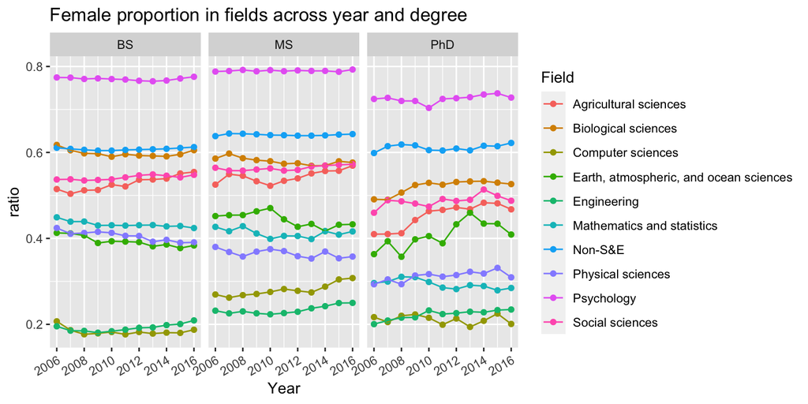

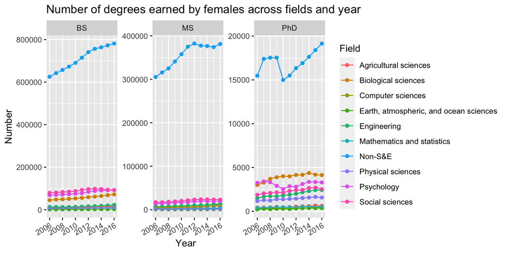

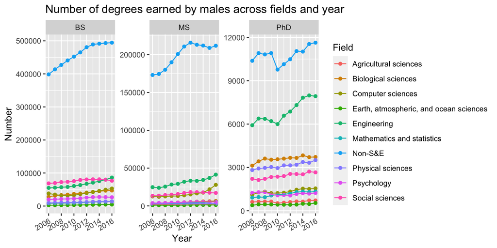

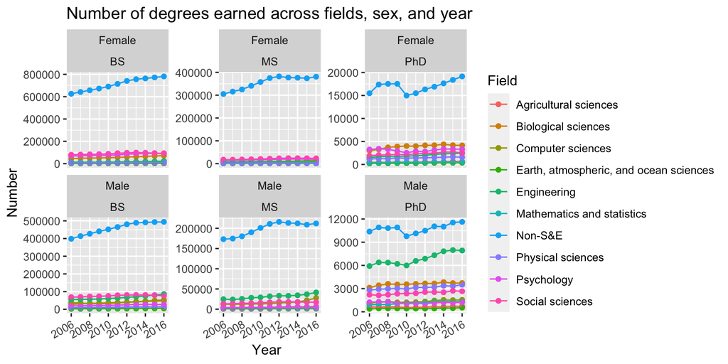

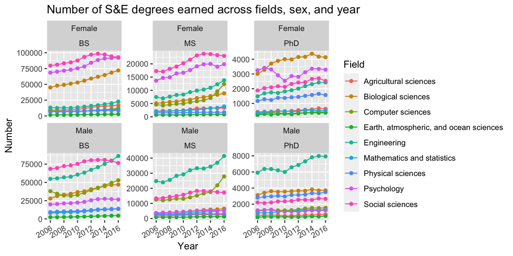

## 3.5 Women in Data Science

Finally, is there evidence showing that women are underrepresented in data science? Data science is an interdisciplinary field of computer science, math, and statistics. You may include year and/or degree.

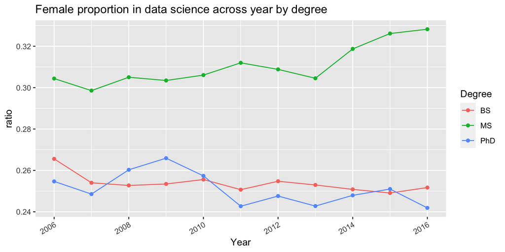

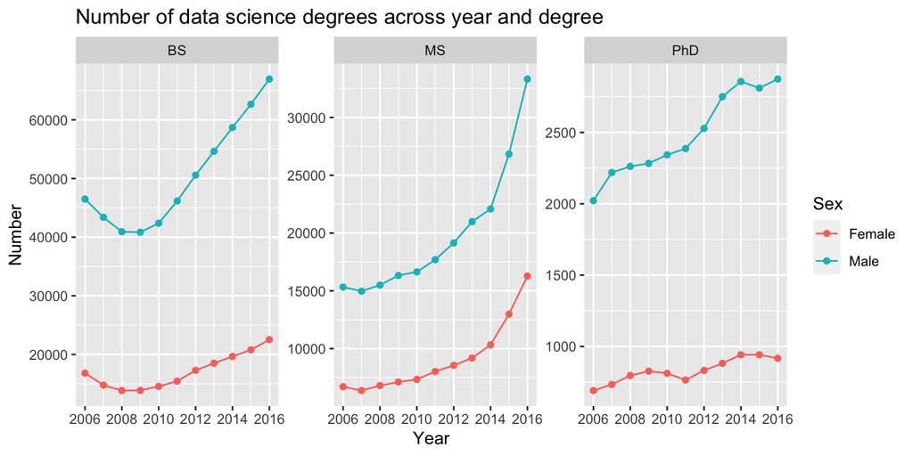

## 3.6 Final brief report

Summarize your findings focusing on answering the questions regarding if we see consistent patterns that more males pursue science-related fields. Any concerns with the data set? How could we improve on the study?

One concern with this dataset is that we can only see the number of degrees earned by women and men across years and fields. It does not give us any information, such as in-major GPAs, of how well women and men did in their degrees. Without this information, there is no way to measure how successful women and men are at completing their degrees, which could also impact their future career outcomes. Additionally, without career outcome information, we cannot conclusively state that science-related fields are male dominated in the workforce. Another concern is that this dataset only provides information up until 2016, which bars us from analyzing the gender difference in science-related fields in more recent years.

## 3.7 Appendix

To help out, we have included some R-codes here as references. You should make your own chunks filled with texts going through each items listed above. Make sure to hide the unnecessary outputs/code etc.

1. Clean data
2. A number of sample analyses

# 4 Case study 3: Major League Baseball

We would like to explore how payroll affects performance among Major League Baseball teams. The data is prepared in two formats record payroll, winning numbers/percentage by team from 1998 to 2014.

Here are the datasets:

-`MLPayData_Total.csv`: wide format -`baseball.csv`: long format

Feel free to use either dataset to address the problems.

## 4.1 EDA: Relationship between payroll changes and performance

Payroll may relate to performance among ML Baseball teams. One possible argument is that what affects this year’s performance is not this year’s payroll, but the amount that payroll increased from last year. Let us look into this through EDA.

Create increment in payroll

a). To describe the increment of payroll in each year there are several possible approaches. Take 2013 as an example:

```
- option 1: diff: payroll_2013 - payroll_2012
- option 2: log diff: log(payroll_2013) - log(payroll_2012)
```

Explain why the log difference is more appropriate in this setup.

In this set up, the log difference is more appropriate because it allows us to get a better understanding of the percentage change of payroll between each year. Since players have different magnitudes in pay, taking the log allows us to base our analysis on the percentage change.

b). Create a new variable `diff_log=log(payroll_2013) - log(payroll_2012)`. Hint: use `dplyr::lag()` function.

```r
# Read in .csv data using better tidyverse function read_csv :)
baseball <- read_csv("./data/baseball.csv")
# Examine the data structure:
# str(baseball)
# head(baseball)

# Create a new table with the log difference
baseball_log_diff <- baseball |>
  group_by(team) |> # group by team in ascending order
  mutate(log_pay = log(payroll)) |> # create new variable log_pay
  mutate(diff_log = log_pay - lag(log_pay)) |> # create new variable diff_log
  ungroup() # ungroup the data

# Check table is correct:
# str(baseball_log_diff)
head(baseball_log_diff, 20)
```

[output not shown]

c). Create a long data table including: team, year, diff_log, win_pct

```r
# Create a new long data table
baseball_long <- baseball_log_diff |>
  select(team, year, diff_log, win_pct) |> # select the relevant columns
  filter(!is.na(diff_log)) # remove NA values for diff_log

# Check table is correct:
# str(baseball_long)
head(baseball_long, 20)
```

[output not shown]

## 4.2 Exploratory questions

a). Which five teams had the highest increase in their payroll between years 2010 and 2014, inclusive?

```r
# Print table of top 5 teams with increase in payroll between 2010 and 2014
baseball_long |>
  filter(year > 2010 & year <= 2014) |> # filter for years 2011 to 2014
  group_by(team) |> # group by team
  summarize(
    diff_log_2010_2014 = sum(diff_log), # sum diff_long to find total increase
    percent_change_2010_2014 = (exp(diff_log_2010_2014) - 1) * 100 # convert to percentage
  ) |>
  arrange(desc(diff_log_2010_2014)) |> # arrange in descending order
  head(5) |> # select the top 5 teams
  pander() # print table in pretty format
```

[output not shown]

b). Between 2010 and 2014, inclusive, which team(s) “improved” the most? That is, had the biggest percentage gain in wins? The Pittsburgh Pirates improved the most.

## 4.3 Do log increases in payroll imply better performance?

Is there evidence to support the hypothesis that higher increases in payroll on the log scale lead to increased performance?

Pick up a few statistics, accompanied with some data visualization, to support your answer.

## 4.4 Comparison

Which set of factors are better explaining performance? Yearly payroll or yearly increase in payroll? What criterion is being used?